# Course5_Project_1

Ruobin Wu

1/3/2017

# Instructions

It is now possible to collect a large amount of data about personal movement using activity monitoring devices such as a Fitbit, Nike Fuelband, or Jawbone Up. These type of devices are part of the “quantified self” movement – a group of enthusiasts who take measurements about themselves regularly to improve their health, to find patterns in their behavior, or because they are tech geeks. But these data remain under-utilized both because the raw data are hard to obtain and there is a lack of statistical methods and software for processing and interpreting the data.

This assignment makes use of data from a personal activity monitoring device. This device collects data at 5 minute intervals through out the day. The data consists of two months of data from an anonymous individual collected during the months of October and November, 2012 and include the number of steps taken in 5 minute intervals each day.

# Data:

The data for this assignment can be downloaded from the course web site:

Dataset: Activity monitoring data [52K] The variables included in this dataset are:

steps: Number of steps taking in a 5-minute interval (missing values are coded as 𝙽𝙰) date: The date on which the measurement was taken in YYYY-MM-DD format interval: Identifier for the 5-minute interval in which measurement was taken The dataset is stored in a comma-separated-value (CSV) file and there are a total of 17,568 observations in this dataset.

# Assignment

## Loading and preprocessing the data

```r
#Load the data
data <- read.csv("activity.csv", header = T)
#view the data
str(data)
```

```
## 'data.frame':    17568 obs. of  3 variables:
##  $ steps   : int  NA NA NA NA NA NA NA NA NA NA ...
##  $ date    : Factor w/ 61 levels "2012-10-01","2012-10-02",..: 1 1 1 1 1 1 1 1 1 1 ...
##  $ interval: int  0 5 10 15 20 25 30 35 40 45 ...
```

```r
head(data)
```

```
##   steps       date interval
## 1    NA 2012-10-01        0
## 2    NA 2012-10-01        5
## 3    NA 2012-10-01       10
## 4    NA 2012-10-01       15
## 5    NA 2012-10-01       20
## 6    NA 2012-10-01       25
```

```r
summary(data)
```

```
##      steps                date          interval
##  Min.   :  0.00   2012-10-01:  288   Min.   :   0.0
##  1st Qu.:  0.00   2012-10-02:  288   1st Qu.: 588.8
##  Median :  0.00   2012-10-03:  288   Median :1177.5
##  Mean   : 37.38   2012-10-04:  288   Mean   :1177.5
##  3rd Qu.: 12.00   2012-10-05:  288   3rd Qu.:1766.2
##  Max.   :806.00   2012-10-06:  288   Max.   :2355.0
##  NA's   :2304     (Other)   :15840
```

```r
#Process/transform the data
data$date <- as.Date(data$date, format = "%Y-%m-%d")
data$interval <- factor(data$interval)
```

## What is mean total number of steps taken per day?

```
1. Calculate the total number of steps taken per day
```

```r
#remove na data
data2 <- na.omit(data)
head(data2)
```

```
##     steps       date interval
## 289     0 2012-10-02        0
## 290     0 2012-10-02        5
## 291     0 2012-10-02       10
## 292     0 2012-10-02       15
## 293     0 2012-10-02       20
## 294     0 2012-10-02       25
```

```r
#get total steps per day

total_steps <- aggregate(steps~date, data= data2, sum)

total_steps
```

```
##          date steps
## 1  2012-10-02   126
## 2  2012-10-03 11352
## 3  2012-10-04 12116
## 4  2012-10-05 13294
## 5  2012-10-06 15420
## 6  2012-10-07 11015
## 7  2012-10-09 12811
## 8  2012-10-10  9900
## 9  2012-10-11 10304
## 10 2012-10-12 17382
## 11 2012-10-13 12426
## 12 2012-10-14 15098
## 13 2012-10-15 10139
## 14 2012-10-16 15084
```

[output cut: 39 more lines]

```
2. Make a histogram of the total number of steps taken each day
```

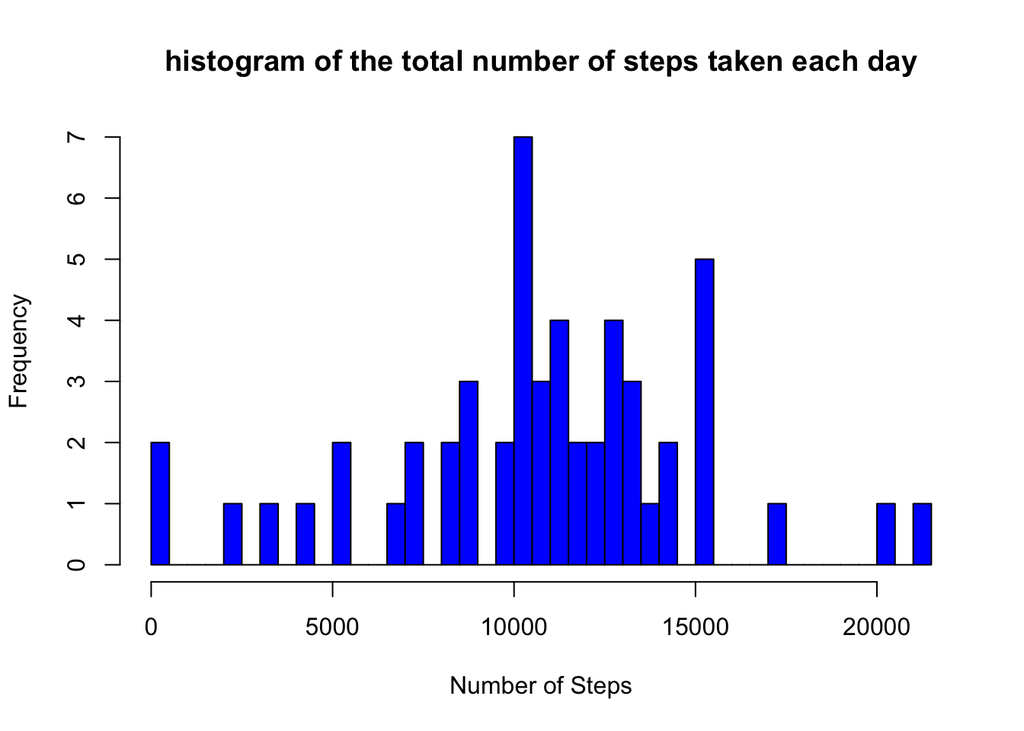

[output not shown]

```r
hist(total_steps$steps, main = "histogram of the total number of steps taken each day", breaks = 50, xlab = "Number of Steps", col = "blue")
```

```r
mean_steps <- mean(total_steps$steps)
median_steps <- median(total_steps$steps)

mean_steps
```

```
## [1] 10766.19
```

```r
median_steps
```

```
## [1] 10765
```

The mean steps is 10766.19 The median steps is 10765

## What is the average daily activity pattern?

```
1. Make a time series plot of the 5-minute interval (x-axis) and the average number of steps taken, averaged across all days (y-axis)
```

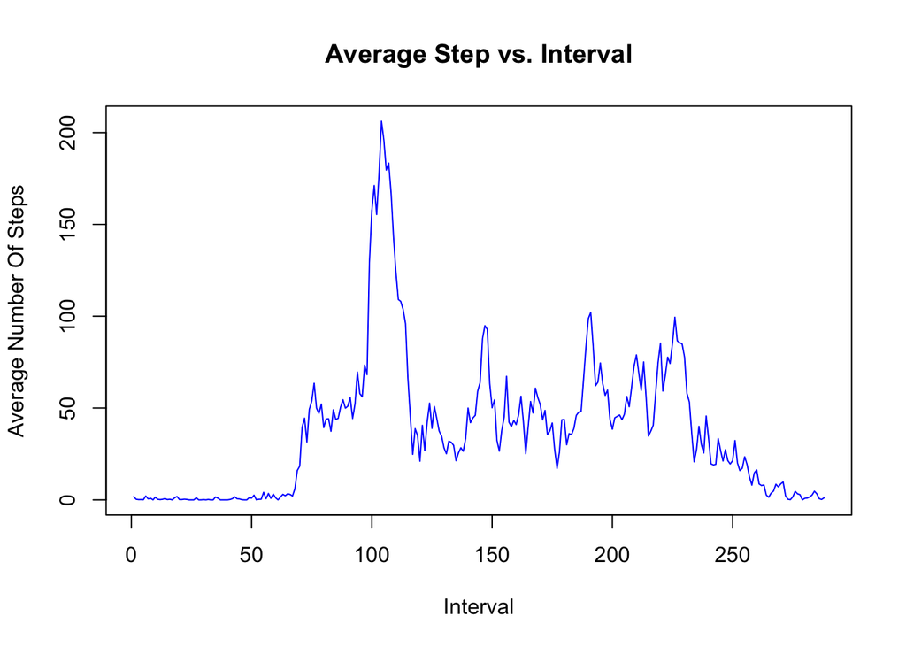

[output not shown]

```r
#calculat the average steps

average_steps <- aggregate(steps~interval, data= data2, mean)

#plot the data

plot(y = average_steps$steps, x = as.integer(average_steps$interval), type="l", xlab = "Interval", ylab = "Average Number Of Steps", main = "Average Step vs. Interval", col = "blue" )
```

```r
max(average_steps$steps)
```

```
## [1] 206.1698
```

```r
average_steps[average_steps$steps == (max(average_steps$steps)),]$interval
```

```
## [1] 835
## 288 Levels: 0 5 10 15 20 25 30 35 40 45 50 55 100 105 110 115 120 ... 2355
```

The 5-minute interval that contains the maximum number of steps (206.1698 steps ) is the interval 835.

## Imputing missing values

```
1. Calculate and report the total number of missing values in the dataset
```

```r
nrow(data) - nrow(data2)
```

```
## [1] 2304
```

There are 2304 missing values in the dataset.

```
2. Devise a strategy for filling in all of the missing values in the dataset. The strategy does not need to be sophisticated. For example, you could use the mean/median for that day, or the mean for that 5-minute interval, etc.
```

```r
# use the mean of the 5-minute interval to fill the missing value
na_rows <- subset(data, is.na(data$steps))

fill_fun <- function(x){
 v= average_steps[average_steps$interval == x,]$steps
 return(v)
}

na_rows$steps <- unlist(lapply(na_rows$interval, fill_fun))
```

```
3. Create a new dataset that is equal to the original dataset but with the missing data filled in.
```

```r
final <- rbind(na_rows, data2)
str(final)
```

```
## 'data.frame':    17568 obs. of  3 variables:
##  $ steps   : num  1.717 0.3396 0.1321 0.1509 0.0755 ...
##  $ date    : Date, format: "2012-10-01" "2012-10-01" ...
##  $ interval: Factor w/ 288 levels "0","5","10","15",..: 1 2 3 4 5 6 7 8 9 10 ...
```

```r
head(final)
```

```
##       steps       date interval
## 1 1.7169811 2012-10-01        0
## 2 0.3396226 2012-10-01        5
## 3 0.1320755 2012-10-01       10
## 4 0.1509434 2012-10-01       15
## 5 0.0754717 2012-10-01       20
## 6 2.0943396 2012-10-01       25
```

```r
summary(final)
```

```
##      steps             date               interval
##  Min.   :  0.00   Min.   :2012-10-01   0      :   61
##  1st Qu.:  0.00   1st Qu.:2012-10-16   5      :   61
##  Median :  0.00   Median :2012-10-31   10     :   61
##  Mean   : 37.38   Mean   :2012-10-31   15     :   61
##  3rd Qu.: 27.00   3rd Qu.:2012-11-15   20     :   61
##  Max.   :806.00   Max.   :2012-11-30   25     :   61
##                                        (Other):17202
```

[output not shown]

```r
#calculate total steps
total_final <- aggregate(steps~date, data= final, sum)

#calculate the mean and median
mean_final <- mean(total_final$steps)
median_final <- median(total_final$steps)

mean_final
```

```
## [1] 10766.19
```

```r
median_final
```

```
## [1] 10766.19
```

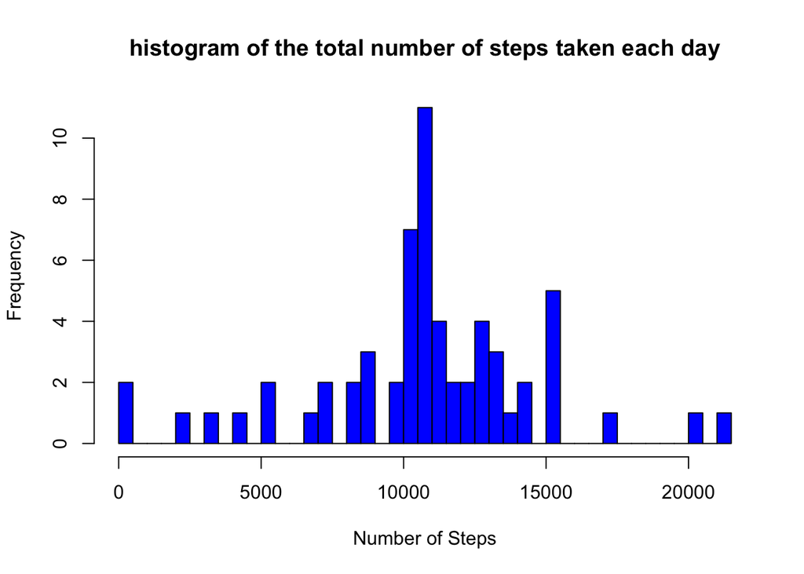

```r
#plot
hist(total_final$steps, main = "histogram of the total number of steps taken each day", breaks = 50, xlab = "Number of Steps", col = "blue")
```

The new mean steps is 10766.19 and the new median steps is 10766.19. Mean steps are the same but median steps are different from the old one. Imputing missing data may change median.

## Are there differences in activity patterns between weekdays and weekends?

```
1. Create a new factor variable in the dataset with two levels – “weekday” and “weekend” indicating whether a given date is a weekday or weekend day.
```

```r
days <- weekdays(final$date)
weekday <- c("Monday", "Tuesday", "Wednesday" , "Thursday", "Friday")
weekend <- c("Saturday", "Sunday")
days[days %in% weekday] <- "weekday"
days[days %in% weekend] <- "weekend"
table(days)
```

```
## days
## weekday weekend
##   12960    4608
```

```r
final$days <- factor(days)

head(final)
```

```
##       steps       date interval    days
## 1 1.7169811 2012-10-01        0 weekday
## 2 0.3396226 2012-10-01        5 weekday
## 3 0.1320755 2012-10-01       10 weekday
## 4 0.1509434 2012-10-01       15 weekday
## 5 0.0754717 2012-10-01       20 weekday
## 6 2.0943396 2012-10-01       25 weekday
```

[output not shown]

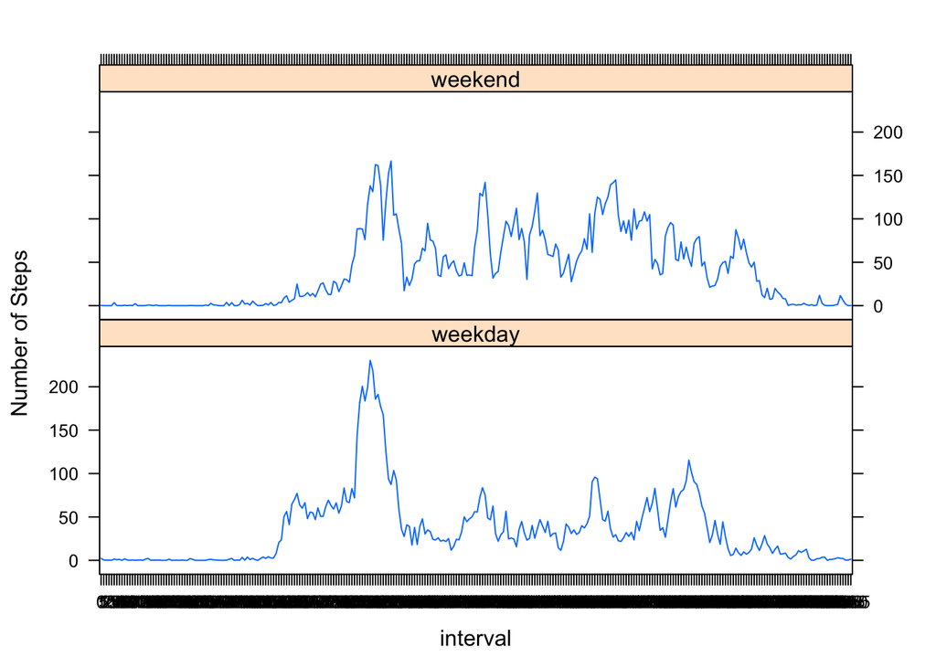

```r
library(lattice)

#calculate average steps
average_final_weekday <- aggregate(steps~ interval, data= final[final$days == "weekday",], mean )

average_final_weekday$day <- "weekday"

average_final_weekend <- aggregate(steps~ interval, data= final[final$days == "weekend",], mean )

average_final_weekend$day <- "weekend"

average_final <- rbind(average_final_weekend, average_final_weekday)

xyplot(steps~ interval | day, data = average_final, layout = c(1,2), type = "l", ylab = "Number of Steps")
```

The plot shows that that activity on the weekends is higher than activity on the weekdays.